# Johanes Andrian Kartono 03729894

## Verification

#### Task 4.2.1: Auto Correlation

```python
%load_ext autoreload
%autoreload 2
```

```python
import simstudy4

simstudy4.task_4_2_1()
```

```
Name: autocorr 1
Lag = 0; covariance = 25.0; correlation = 0.99995
Lag = 1; covariance = -25.0; correlation = -0.99995
Name: autocorr 2
Lag = 0; covariance = 14.75; correlation = 0.99995
Lag = 1; covariance = -12.25; correlation = -0.8304669491525424
Lag = 2; covariance = 9.75; correlation = 0.6609838983050847
Lag = 3; covariance = -12.25; correlation = -0.8304669491525424
```

## Simulation Study

#### Task 4.3.1: Correlations in the DES

Calculate the above correlations and autocorrelations for a system with a single server with the service rate µ = 0.015 and two users, the arrival rate of which is varied such that the offered traffic is varied in the list A = 0.01,0.5,0.8,0.95. The queue size should be infinite (you can set it to 10000) and the simulation time should be 10000 seconds. Use the implemented heatmap to visualize correlations.

```
simulation with offered traffic of 0.01
Name: accumulated iat with lags 1 to 10
Lag = 0; covariance = 40760140.48804856; correlation = 0.9993377483443708
Lag = 1; covariance = 654000.9984159917; correlation = 0.016034485586811035
Lag = 2; covariance = 688887.9811454266; correlation = 0.0168898280451518
Lag = 3; covariance = -960955.3844211698; correlation = -0.023560247306027564
Lag = 4; covariance = -372176.3520258367; correlation = -0.009124842877555257
Lag = 5; covariance = 117772.39052391797; correlation = 0.002887487485422572
Lag = 6; covariance = 568383.904461503; correlation = 0.013935366377019434
Lag = 7; covariance = -972818.1060015708; correlation = -0.023851091874555735
Lag = 8; covariance = 407804.2040075585; correlation = 0.009998349616036694
Lag = 9; covariance = 818200.9303121641; correlation = 0.020060261461345468
Lag = 10; covariance = -1979043.773499526; correlation = -0.04852125446093255
Name: waiting time with lags 1 to 20
Lag = 0; covariance = 243.103507727062; correlation = 0.9993381866313693
Lag = 1; covariance = 151.74485819904172; correlation = 0.6237854518887459
Lag = 2; covariance = 68.40961785618852; correlation = 0.281214961049853
Lag = 3; covariance = -0.917821081552567; correlation = -0.0037729346806487127
Lag = 4; covariance = -0.917821081552567; correlation = -0.0037729346806487127
Lag = 5; covariance = -0.917821081552567; correlation = -0.003772934680648713
Lag = 6; covariance = -0.917821081552567; correlation = -0.003772934680648713
Lag = 7; covariance = -0.917821081552567; correlation = -0.003772934680648713
Lag = 8; covariance = -0.917821081552567; correlation = -0.0037729346806487127
Lag = 9; covariance = -0.917821081552567; correlation = -0.003772934680648713
Lag = 10; covariance = -0.917821081552567; correlation = -0.003772934680648713
Lag = 11; covariance = -0.917821081552567; correlation = -0.003772934680648713
Lag = 12; covariance = -0.917821081552567; correlation = -0.0037729346806487127
Lag = 13; covariance = -0.917821081552567; correlation = -0.003772934680648713
Lag = 14; covariance = -0.917821081552567; correlation = -0.003772934680648713
Lag = 15; covariance = -0.917821081552567; correlation = -0.003772934680648713
Lag = 16; covariance = -0.917821081552567; correlation = -0.0037729346806487127
Lag = 17; covariance = 12.069315882713523; correlation = 0.04961396222079056
Lag = 18; covariance = 13.184248637117797; correlation = 0.05419717406919061
Lag = 19; covariance = 15.352397009589517; correlation = 0.06310989393552122
Lag = 20; covariance = -0.917821081552567; correlation = -0.003772934680648713
```

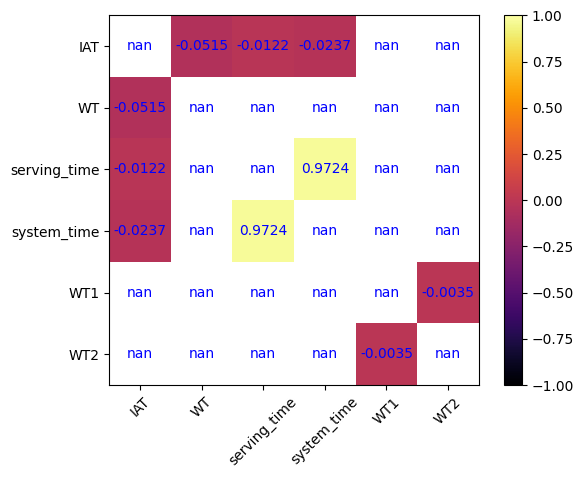

```python
# separated as 4 separate function calls to prevent output being too long per code block
simstudy4.task_4_3_1(0.01)
```

```
simulation with offered traffic of 0.5
Name: accumulated iat with lags 1 to 10
Lag = 0; covariance = 17918.22502581326; correlation = 0.9999866243997699
Lag = 1; covariance = -60.61691756765504; correlation = -0.0033829303233257764
Lag = 2; covariance = 38.59188609240664; correlation = 0.0021537495955749435
Lag = 3; covariance = 24.278397041442076; correlation = 0.001354937348332978
Lag = 4; covariance = -85.81887748740337; correlation = -0.0047894101946356635
Lag = 5; covariance = 36.07525215179703; correlation = 0.0020133004006633584
Lag = 6; covariance = -61.194951794241206; correlation = -0.0034151894613932317
Lag = 7; covariance = 77.39136624313687; correlation = 0.004319084673603054
Lag = 8; covariance = 45.98224678991755; correlation = 0.0025661934529522313
Lag = 9; covariance = 105.00085768029021; correlation = 0.00585992491329528
Lag = 10; covariance = -15.482015474844957; correlation = -0.0008640257822017464
Name: waiting time with lags 1 to 20
Lag = 0; covariance = 13811.695432502816; correlation = 0.99998662439977
Lag = 1; covariance = 10867.441103042314; correlation = 0.7868183741527333
Lag = 2; covariance = 8729.11374070522; correlation = 0.6320003960576533
Lag = 3; covariance = 7077.587172059171; correlation = 0.5124274959341507
Lag = 4; covariance = 5767.107325733028; correlation = 0.4175468692742461
Lag = 5; covariance = 4730.321266159721; correlation = 0.3424820666217323
Lag = 6; covariance = 3919.213225996202; correlation = 0.2837566773260858
Lag = 7; covariance = 3261.5800434815974; correlation = 0.23614308857517247
Lag = 8; covariance = 2743.925239834498; correlation = 0.19866413588372975
Lag = 9; covariance = 2307.5718524776294; correlation = 0.16707152272477233
Lag = 10; covariance = 1937.7351319687405; correlation = 0.140294811963366
Lag = 11; covariance = 1609.827386419718; correlation = 0.11655381932502151
Lag = 12; covariance = 1312.2605713747243; correlation = 0.09500955371589255
Lag = 13; covariance = 1095.5039167087152; correlation = 0.07931606000435541
Lag = 14; covariance = 905.6413656304785; correlation = 0.06556973809329873
Lag = 15; covariance = 747.0319508043749; correlation = 0.054086188220288184
Lag = 16; covariance = 683.2041876467565; correlation = 0.04946496631926276
Lag = 17; covariance = 621.5239473296542; correlation = 0.04499922816218491
Lag = 18; covariance = 568.138770378252; correlation = 0.04113406452941406
Lag = 19; covariance = 491.7772561653419; correlation = 0.03560538101586617
Lag = 20; covariance = 403.88552782292845; correlation = 0.029241893407316647
```

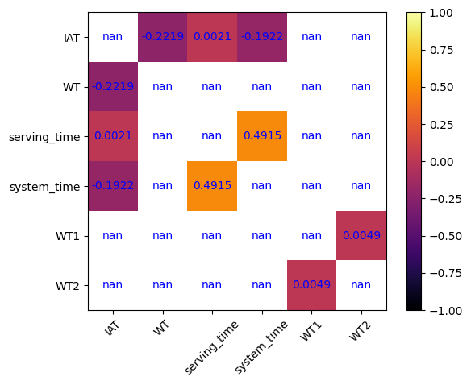

```python
simstudy4.task_4_3_1(0.5)
```

```
simulation with offered traffic of 0.8
Name: accumulated iat with lags 1 to 10
Lag = 0; covariance = 6962.729260216061; correlation = 0.9999916958695254
Lag = 1; covariance = 11.270346918101495; correlation = 0.001618654539975674
Lag = 2; covariance = -13.80194713828223; correlation = -0.0019822446068632725
Lag = 3; covariance = 46.79729168154154; correlation = 0.0067210574074904345
Lag = 4; covariance = -11.94758761133562; correlation = -0.0017159202879358396
Lag = 5; covariance = -6.2168139633431565; correlation = -0.0008928628567579771
Lag = 6; covariance = -1.29888157766527; correlation = -0.0001865462152901336
Lag = 7; covariance = -35.427609089669204; correlation = -0.005088136213568868
Lag = 8; covariance = -7.563846126877252; correlation = -0.001086324490445204
Lag = 9; covariance = -14.333424748822836; correlation = -0.002058575766271974
Lag = 10; covariance = 7.699556861998644; correlation = 0.001105815354313366
Name: waiting time with lags 1 to 20
Lag = 0; covariance = 127595.33006719343; correlation = 0.9999916955247183
Lag = 1; covariance = 123549.31369589725; correlation = 0.9682822060855472
Lag = 2; covariance = 119825.95161047713; correlation = 0.9391014267976926
Lag = 3; covariance = 116340.51486519496; correlation = 0.9117853189219308
Lag = 4; covariance = 113007.54701216; correlation = 0.885664142130189
Lag = 5; covariance = 109862.57774287926; correlation = 0.8610163501592367
Lag = 6; covariance = 106924.71560999329; correlation = 0.8379917007936574
Lag = 7; covariance = 104152.66149666671; correlation = 0.816266524085294
Lag = 8; covariance = 101513.90340935995; correlation = 0.7955860166371308
Lag = 9; covariance = 99024.56382328334; correlation = 0.7760765337108619
Lag = 10; covariance = 96654.70144193726; correlation = 0.757503419008039
Lag = 11; covariance = 94382.69876451923; correlation = 0.7396972515845801
Lag = 12; covariance = 92221.23730553525; correlation = 0.7227574191624807
Lag = 13; covariance = 90119.12902586228; correlation = 0.7062827502097867
Lag = 14; covariance = 88108.51113693476; correlation = 0.6905251108765749
Lag = 15; covariance = 86197.76698456267; correlation = 0.6755502032240903
Lag = 16; covariance = 84381.31184803009; correlation = 0.6613142586102143
Lag = 17; covariance = 82619.4613257553; correlation = 0.6475062619531041
Lag = 18; covariance = 80926.43924623543; correlation = 0.6342376884170013
Lag = 19; covariance = 79291.332898081; correlation = 0.6214230127655248
Lag = 20; covariance = 77673.46206045985; correlation = 0.6087434154699123
```

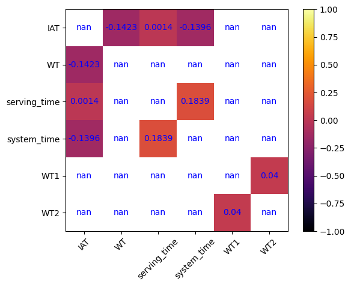

```python
simstudy4.task_4_3_1(0.8)
```

```
simulation with offered traffic of 0.95
Name: accumulated iat with lags 1 to 10
Lag = 0; covariance = 4964.271992240806; correlation = 0.9999929671071606
Lag = 1; covariance = -10.550115137328248; correlation = -0.0021251939772818323
Lag = 2; covariance = -1.177705923603753; correlation = -0.00023723471291761333
Lag = 3; covariance = -4.215019846188625; correlation = -0.0008490651215311715
Lag = 4; covariance = -19.69081644805192; correlation = -0.00396647846762357
Lag = 5; covariance = 16.573290097763675; correlation = 0.003338490228878356
Lag = 6; covariance = 0.41341674428440456; correlation = 8.327783759933236e-05
Lag = 7; covariance = -0.9105736924457233; correlation = -0.0001834241334684613
Lag = 8; covariance = -4.676928942225459; correlation = -0.0009421111609507726
Lag = 9; covariance = 32.440872708091774; correlation = 0.006534824160645381
Lag = 10; covariance = 10.998305958013589; correlation = 0.0022154766349016903
Name: waiting time with lags 1 to 20
Lag = 0; covariance = 989785.731872174; correlation = 0.9999929657714441
Lag = 1; covariance = 985433.608962137; correlation = 0.9955959612925276
Lag = 2; covariance = 981189.0099062291; correlation = 0.9913075895149314
Lag = 3; covariance = 976995.5812625645; correlation = 0.9870709158479981
Lag = 4; covariance = 972863.5558070804; correlation = 0.9828962785938755
Lag = 5; covariance = 968857.7009500461; correlation = 0.978849113081236
Lag = 6; covariance = 964912.5440209182; correlation = 0.9748632714480875
Lag = 7; covariance = 961009.6627781836; correlation = 0.9709201414722758
Lag = 8; covariance = 957147.4740186092; correlation = 0.9670181236236747
Lag = 9; covariance = 953345.9067864986; correlation = 0.9631773524662373
Lag = 10; covariance = 949533.7810035744; correlation = 0.9593259138721996
Lag = 11; covariance = 945774.5588381232; correlation = 0.9555279244678538
Lag = 12; covariance = 942066.9203945005; correlation = 0.9517820507460397
Lag = 13; covariance = 938402.3252668595; correlation = 0.948079664227384
Lag = 14; covariance = 934809.137833508; correlation = 0.9444494217998098
Lag = 15; covariance = 931262.9721496468; correlation = 0.9408666860367737
Lag = 16; covariance = 927770.9952119116; correlation = 0.9373386978450606
Lag = 17; covariance = 924300.651418065; correlation = 0.9338325658905302
Lag = 18; covariance = 920865.119469214; correlation = 0.9303616047805577
Lag = 19; covariance = 917504.7525110643; correlation = 0.9269665838054578
Lag = 20; covariance = 914161.7167534037; correlation = 0.9235890727600524
```

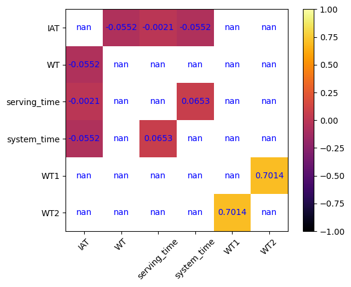

```python
simstudy4.task_4_3_1(0.95)
```

#### Task 4.3.2 The Visualization of Covariance/Correlation

Reuse the scenario parameters of the previous task. Now, we want to have a more direct visualization of the relationship between the following values.

- IAT and serving time of a packet
- serving time and system time of a packet

Please draw scatter plots with different As. In order to retrieve the values, you might have to get access to the inner variables of StatisticCollection. You should have eight plots in total.

```
simulation with offered traffic of 0.01
```

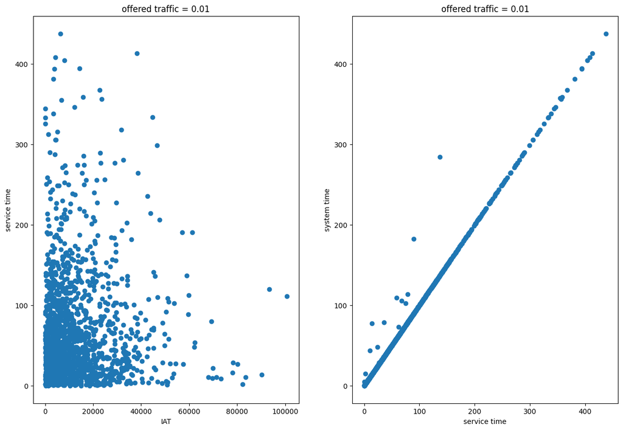

```python
import matplotlib.pyplot as plt

plt.rcParams['figure.figsize'] = [15,10]
simstudy4.task_4_3_2(0.01)
```

```
simulation with offered traffic of 0.5
```

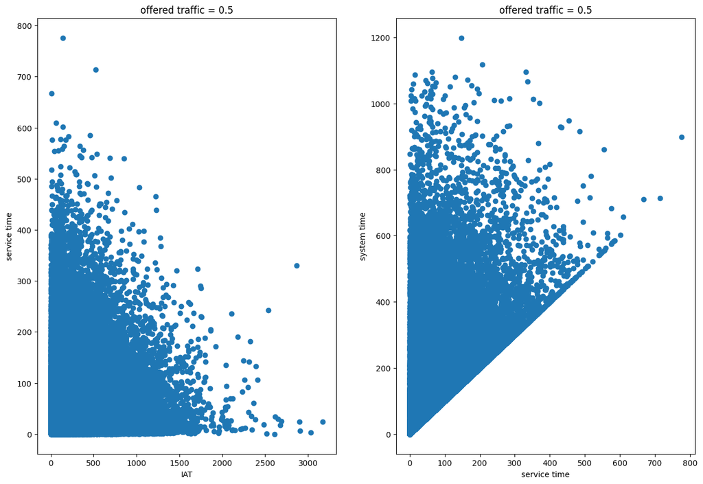

```python
simstudy4.task_4_3_2(0.5)
```

```
simulation with offered traffic of 0.8
```

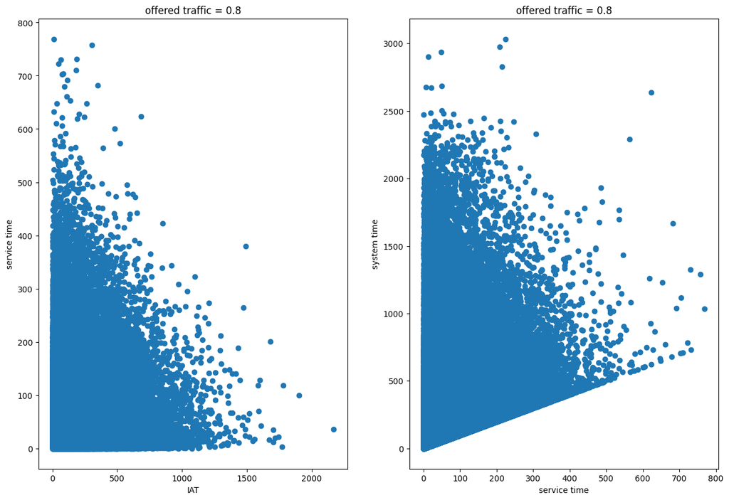

```python
simstudy4.task_4_3_2(0.8)
```

```
simulation with offered traffic of 0.95
```

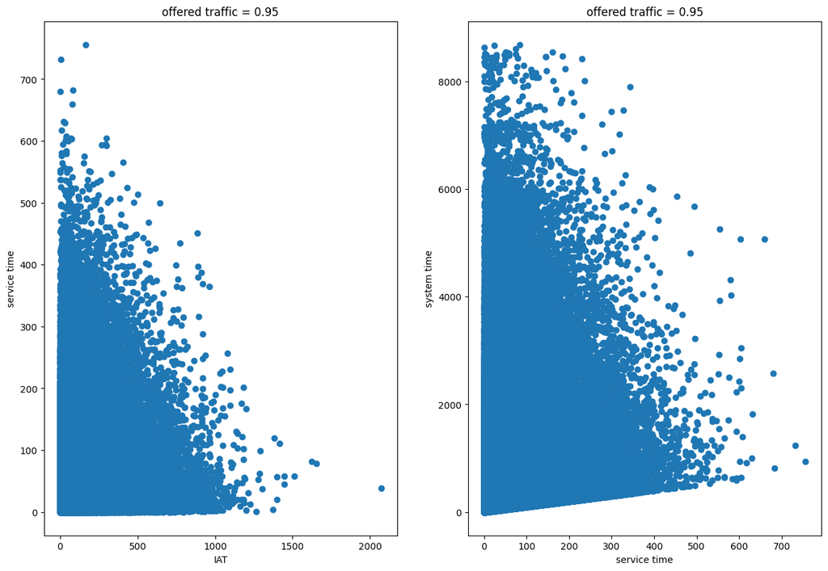

```python
simstudy4.task_4_3_2(0.95)
```